# Analysis of Multiple-Causes Scenario (Study 1a)

Dennis W. H. Teo and Zheng Yong Ang

# 1 Participant Exclusion

> Number of flat responders:

```r
# number of flat responders
sum(ecl_dat$flat)
```

```
## [1] 0
```

```r
# remove flat responders
ecl_dat <- ecl_dat[!ecl_dat$flat, ]
```

> Number of participants who failed first attention check:

```r
# number of participants who failed attention1 check
sum(ecl_dat$attention1 != 2)
```

```
## [1] 1
```

```r
# remove those who failed attention1 check
ecl_dat <- ecl_dat[ecl_dat$attention1=="2",]
```

> Number of participants who failed second attention check:

```r
# number who failed attention2 check
sum(!(ecl_dat$attentionOrange == 0 & ecl_dat$attentionBlue == 0 & ecl_dat$attentionBulb == 1))
```

```
## [1] 25
```

```r
pass_attention2 <- (ecl_dat$attentionOrange == 0 & ecl_dat$attentionBlue == 0 & ecl_dat$attentionBulb == 1)

# remove those who failed attention2 check
ecl_dat <- ecl_dat[pass_attention2, ]
```

> Number of outliers for total time taken:

```r
# outliers for Total Time taken for survey
rt_range <- 3*sd(ecl_dat$totalRT)
slow <- which(ecl_dat$totalRT > mean(ecl_dat$totalRT,na.rm = T) + rt_range)
fast <- which(ecl_dat$totalRT < mean(ecl_dat$totalRT,na.rm = T) - rt_range)

# number of outliers for Total Time taken for survey
length(slow)
```

```
## [1] 3
```

```r
length(fast)
```

```
## [1] 0
```

```r
# remove outliers
ecl_dat <- ecl_dat[-slow,]
```

> Number of participants who failed anti-bot verification:

```r
n_fails <- which(ecl_dat$nFails > 3)
# number who failed bot check (more than 3 times)
length(n_fails)
```

```
## [1] 0
```

> Number of remaining participants after data cleaning:

```r
# number of participants in each condition (after exclusions)
ecl_dat$condition <- relabel(ecl_dat$condition,
                             from = c("condition 2","condition 1"),
                             to = c("no-emotion", "emotion"))

table(ecl_dat$condition)
```

```
##
##    emotion no-emotion
##         59         70
```

```r
emotion_dat <- ecl_dat %>%
  filter(condition=="emotion")
noemotion_dat <- ecl_dat %>%
  filter(condition=="no-emotion")
```

# 2 Summary Statistics

- `relationBlue`: likelihood that blue caused bulb to light up
- `relationOrange`: likelihood that orange caused bulb to light up
- `relationOrangeBlue`: likelihood that both caused bulb to light up
- `expBlue`: likelihood that agent expected blue to cause bulb to light up
- `expOrange`: likelihood that agent expected orange to cause bulb to light up
- `expBoth`: likelihood that agent expected both to cause bulb to light up
- `desire`: likelihood that agent desired to bulb to light up
- `knowledge`: likelihood that agent knew how to turn on the bulb

```r
# scaling desire and knowledge variables
ecl_dat$desire <- (ecl_dat$desire - 1)/8
ecl_dat$knowledge <- (ecl_dat$knowledge1 - 1)/8
```

```r
# note these are all normalized ratings which were originally measured using Likert scales
human_cause_data <- gather.keep(ecl_dat, var.to.gather = c("relationBlueNorm", "relationOrangeNorm", "relationOrangeBlueNorm"), keep = c("id", "condition"), key = "structure",value="likelihood")

human_expectation_data <- gather.keep(ecl_dat, var.to.gather = c("expBlueNorm", "expOrangeNorm","expBothNorm"), keep = c("id", "condition"), key = "structure",value="likelihood")

human_desire_data <- gather.keep(ecl_dat, var.to.gather = c("desire"), keep = c("id", "condition"), key = "structure",value="likelihood")

human_knowledge_data <- gather.keep(ecl_dat, var.to.gather = c("knowledge"), keep = c("id", "condition"), key = "structure",value="likelihood")
```

```r
set.seed(100)

human_cause <- human_cause_data %>% group_by(condition, structure)%>%
  multi_boot_standard(col="likelihood")

human_expectation <- human_expectation_data %>% group_by(condition, structure)%>%
  multi_boot_standard(col="likelihood")

human_desire <- human_desire_data %>% group_by(condition, structure)%>%
  multi_boot_standard(col="likelihood")

human_knowledge <- human_knowledge_data %>% group_by(condition, structure)%>%
  multi_boot_standard(col="likelihood")
```

```r
library(psych)

key_variables1 <- c("relationBlueNorm", "relationOrangeNorm", "relationOrangeBlueNorm", "expBlueNorm", "expOrangeNorm","expBothNorm","desire", "knowledge")

table1 <- ecl_dat[,key_variables1] %>%
  describe()%>%
  as.data.frame()%>%
  select(n,mean,sd,median,min,max,skew,kurtosis)
knitr::kable(table1)
```

|  | n | mean | sd | median | min | max | skew | kurtosis |
| --- | --- | --- | --- | --- | --- | --- | --- | --- |
| relationBlueNorm | 129 | 0.1835746 | 0.1045498 | 0.1875000 | 0.0555556 | 0.4736842 | 0.4671995 | -0.5364351 |
| relationOrangeNorm | 129 | 0.3492219 | 0.1610238 | 0.3333333 | 0.0526316 | 0.8181818 | 0.3876862 | 0.0030726 |
| relationOrangeBlueNorm | 129 | 0.4672035 | 0.1390340 | 0.4705882 | 0.0909091 | 0.8181818 | 0.6098659 | 1.1443438 |
| expBlueNorm | 129 | 0.3388856 | 0.1434641 | 0.3333333 | 0.0526316 | 0.8181818 | 0.2723856 | 0.6549834 |
| expOrangeNorm | 129 | 0.2892303 | 0.1076335 | 0.2916667 | 0.0555556 | 0.6153846 | -0.0000043 | -0.2280523 |
| expBothNorm | 129 | 0.3718841 | 0.1596838 | 0.3333333 | 0.0526316 | 0.8181818 | 0.8480841 | 1.2271560 |
| desire | 129 | 0.9098837 | 0.1530746 | 1.0000000 | 0.0000000 | 1.0000000 | -3.0962544 | 13.2363661 |
| knowledge | 129 | 0.6501938 | 0.2574002 | 0.7500000 | 0.0000000 | 1.0000000 | -0.5089178 | -0.5366391 |

# 3 Demographics

> Gender of participants:

```r
table(ecl_dat$gender)
```

```
##
## Female   Male  Other
##     54     52      3
```

> Proportion of females amongst participants:

```r
table(ecl_dat$gender)[[1]]/length(ecl_dat$gender)
```

```
## [1] 0.4186047
```

> Mean and SD for age amongst participants:

```r
mean(ecl_dat$age,na.rm = T)
```

```
## [1] 28.79091
```

```r
sd(ecl_dat$age,na.rm = T)
```

```
## [1] 9.163245
```

> Primary language of participants:

```r
table(ecl_dat$language)
```

```
##
##      Afrikaans         Arabic       Chichewa       Croatian          dutch
##              2              1              1              1              1
##          Dutch        english        English        ENglish        ENGLISH
##              1              2             24              1              1
##        Español       estonian       Estonian        Finnish         french
##              1              1              1              1              1
##         French          greek          Greek Greek / German         hebrew
##              2              2              5              1              1
##         Hebrew      Hungarian        IsiZulu        italian        Italian
##              2              2              2              7              5
##        latvian        Latvian        N Sotho        Ndebele         polish
##              1              3              1              1              3
##         Polish     portuguese     Portuguese    Portugueses        Russian
##              6              1              3              1              3
##         Sepedi          Shona        Slovene          Sotho        spanish
##              1              1              1              1              1
##        Spanish        Swedish      Tshivenda         Tswana          Xhosa
##             11              2              1              1              2
##       Xitsonga           zulu           Zulu
##              1              1              1
```

# 4 Visualizing Participants’ Inferences

## 4.1 Belief Inferences

The bar graphs shows participants’ belief inferences for:

- the hypothesis that the agent believed that pushing the blue box would turn on the bulb (blue bar).
- the hypothesis that the agent believed that pushing the orange box would turn on the bulb (orange bar).
- the hypothesis that the agent believed that pushing both boxes would turn on the bulb (green bar).

The bar graphs on the left shows the mean likelihood ratings (normalized) of participants in the emotion condition, whereas the bar graphs on the right shows the mean likelihood ratings (normalized) of participants in the no emotion condition. Error bars represent 95% confidence intervals.

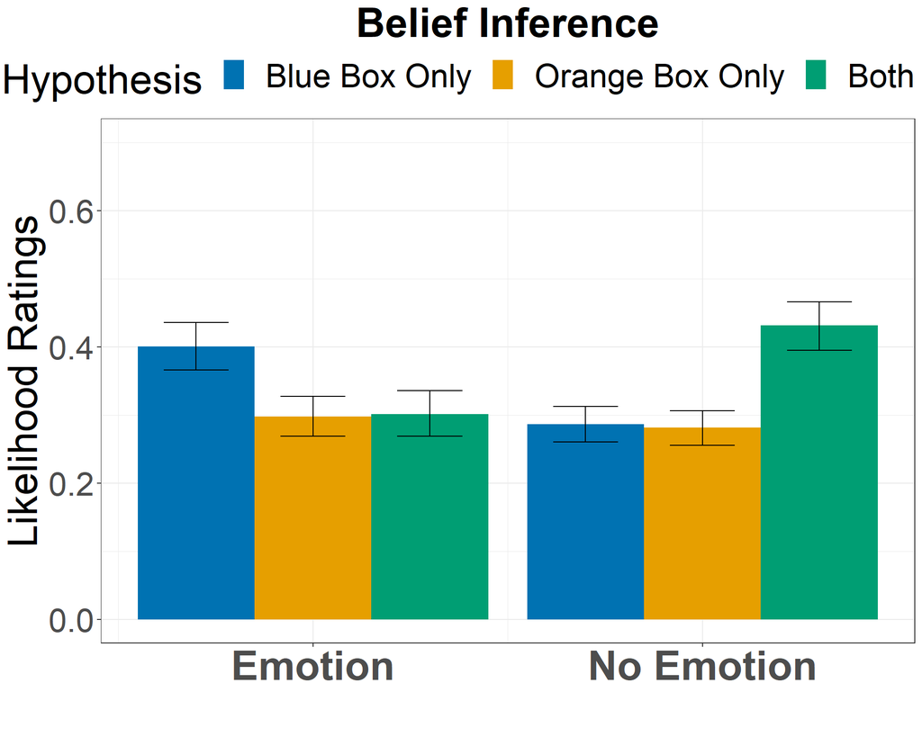

```r
human_expectation$Hypothesis <- factor(human_expectation$structure, labels = c("Blue Box Only", "Orange Box Only","Both Boxes"), levels = c("expBlueNorm", "expOrangeNorm","expBothNorm"))

human_expectation$Condition <- as.numeric(relabel(human_expectation$condition,
                                   from = c("emotion","no-emotion"),
                                   to = rev(c(1,2))
                                   ))

breaks <- unique(human_expectation$Condition)

#999999 - grey
#E69F00 - orange
#56B4E9 - light blue
#009E73 - green
#F0E442 - yellow
#0072B2 - dark blue
#D55E00 - red
#CC79A7 - pink

colorBlindGrey3   <- c("#0072B2", "#E69F00", "#009E73")

plot_human_expectation <- ggplot(human_expectation, aes(x = Condition, y = mean, fill = Hypothesis)) +
  geom_bar(stat = "identity", position = "dodge") +
  geom_errorbar( data = human_expectation, aes(x = Condition,ymin=ci_lower, ymax=ci_upper, fill= Hypothesis), position=position_dodge(.9), width = .5, size = .5)+
  ylab("Likelihood Ratings")  +
  ylim(0,.7) +
  theme_bw() + xlab("")+
  scale_x_reverse(breaks=breaks, labels=c("Emotion", "No Emotion")) +
  scale_fill_manual(values = colorBlindGrey3) +
  theme(text = element_text(size = 32),
        axis.text.x = element_text(face = "bold", size = 32, hjust = 0.5),
        plot.title = element_text(face = "bold", size = 32, hjust = 0.5),
        legend.position="top")  +
  ggtitle("Belief Inference")

plot_human_expectation
```

## 4.2 Causal Inferences

The bar graphs shows participants’ causal inferences for:

- the hypothesis that pushing the blue box caused the bulb to light up (blue bar).
- the hypothesis that pushing the orange box caused the bulb to light up (orange bar).
- the hypothesis that pushing both boxes caused the bulb to light up (green bar).

The bar graphs on the left shows the mean likelihood ratings (normalized) of participants in the emotion condition, whereas the bar graphs on the right shows the mean likelihood ratings (normalized) of participants in the no emotion condition. Error bars represent 95% confidence intervals.

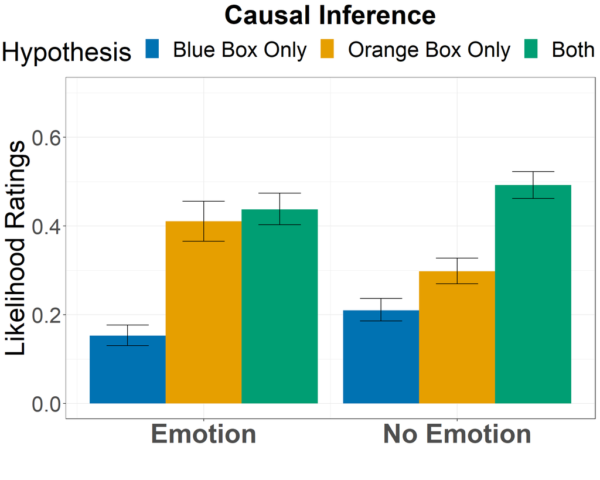

```r
human_cause$Hypothesis <- factor(human_cause$structure, labels = c("Blue Box Only", "Orange Box Only", "Both Boxes"), levels = c("relationBlueNorm", "relationOrangeNorm", "relationOrangeBlueNorm"))

human_cause$Condition <- as.numeric(relabel(human_cause$condition,
                                   from = c("emotion","no-emotion"),
                                   to = rev(c(1,2))
                                   ))

breaks <- unique(human_cause$Condition)

#999999 - grey
#E69F00 - orange
#56B4E9 - light blue
#009E73 - green
#F0E442 - yellow
#0072B2 - dark blue
#D55E00 - red
#CC79A7 - pink

colorBlindGrey3   <- c("#0072B2", "#E69F00", "#009E73")

plot_human_cause <- ggplot(human_cause, aes(x = Condition, y = mean, fill = Hypothesis)) +
  geom_bar(stat = "identity", position = "dodge") +
  geom_errorbar( data = human_cause, aes(x = Condition,ymin=ci_lower, ymax=ci_upper, fill= Hypothesis), position=position_dodge(.9), width = .5, size = .5)+
  ylab("Likelihood Ratings")  +
  ylim(0,.7) +
  theme_bw() + xlab("")+
  scale_x_reverse(breaks=breaks, labels=c( "Emotion","No Emotion")) +
  scale_fill_manual(values = colorBlindGrey3) +
  theme(text = element_text(size = 32),
        axis.text.x = element_text(face = "bold", size = 32, hjust = 0.5),
        plot.title = element_text(face = "bold", size = 32, hjust = 0.5),
        legend.position="top")  +
  ggtitle("Causal Inference")

plot_human_cause
```